# Inference and Linear Regression in R

Associate Professor Ole Maneesoonthorn

Predictive Analytics, Term 4 2020

In this document, you will learn how to conduct statistical inference and analyse the linear regression model in R. You have been exposed to these concepts in Data Analysis, and this document will consolidate the concepts, while giving you an introduction to some of the commonly used tools in R. We will be using the Salary differential example that you may have already seen in Data Analysis for this purpose.

# The Salary Case

The data ‘salary.csv’ comes from the NTC Pay Equity Case. In this case, data on salary of middle managers are provided, alongside their age, experience, gender and education level. From gender profiling, salary discrimination is evident, and there is an ongoing legal battle regarding gender equality. We will use the salary data to help inform if the salary differential is truly driven by gender.

Let us load in the data to have a look at some of the main features.

```r
#Read the data from .csv file.
#Make sure that you have set the working directory to the location of the data file.
salary=read.csv('salary.csv')
#Compute gender specific average salary
mean_M=mean(salary[salary$Gender=="M",'salary'])
mean_F=mean(salary[salary$Gender=="F",'salary'])
mean_M
```

```
## [1] 77.29768
```

```r
mean_F
```

```
## [1] 66.91772
```

```r
#Compute the relative difference from simple average - in percentage
100*(mean_M-mean_F)/mean_F
```

```
## [1] 15.51152
```

The average male salary is $77,298 and the average female salary is $66,918. This amounts to a salary differential of about 15.5%.

### Inference - Is the differential statistically significant?

The assessment of statistical variability can be done very easily in R. The basic “stats” package contains the functions that perform various hypothesis tests. For example, the variability of the sample mean can be assessed using the “t.test” function.

To asssess the salary differential, we conduct a mean difference test between the average male and average female salaries using the t.test function.

```r
#Conduct a t-test of mean difference between the two Genders
#Ha: Two means are not equal
t.test(salary~Gender,data=salary)
```

```
##
##  Welch Two Sample t-test
##
## data:  salary by Gender
## t = -5.9796, df = 137.51, p-value = 1.828e-08
## alternative hypothesis: true difference in means is not equal to 0
## 95 percent confidence interval:
##  -13.812447  -6.947471
## sample estimates:
## mean in group F mean in group M
##        66.91772        77.29768
```

For concrete statistical evidence, we also conduct a one-tailed test, with alternative hypothesis that the mean salary from the female group is less than that of the male group. This involves specifying an additional input in the t.test function as seen below.

```r
#Conduct a t-test of mean difference between the two Genders
#Ha: Mean of females less than mean of males
t.test(salary~Gender,data=salary,alternative="less")
```

```
##
##  Welch Two Sample t-test
##
## data:  salary by Gender
## t = -5.9796, df = 137.51, p-value = 9.138e-09
## alternative hypothesis: true difference in means is less than 0
## 95 percent confidence interval:
##       -Inf -7.505308
## sample estimates:
## mean in group F mean in group M
##        66.91772        77.29768
```

You will notice that that test statistic remain the same. However, the p-value is now smaller than the previous test. Thus, our conclusion here is that there is strong evidence to suggest that mean salary for the female group is less than that of the male group.

### Linear Regression Model - Is gender the only factor driving these differences?

On the surface, the result from the difference in mean analysis indicate that the average female salary is lower than that of their male counterparts. In reality, there may be other factors that determine salary, such as education and experience. To conclude for gender discrimination based on simple average alone may be misleading.

We will use the linear regression modelling mechanism to separate the effect of gender from the effect of the other variables. The linear regression model is the building block of statistical modelling, and the “lm” function built into base R is one of the most commonly used function in R.

In most of R’s statistical modelling function, you will need to specify the “formula” that is the basis of your model. This formula is an expression that specifies how the outcome (or the dependent) variable is related to the explanatory variables. For example, if you wish to regress the variable “y” on “x” you simply specify the model via “y~x” formula. The addition sign “+” specifies a linear combination, so that a multiple regression can be specified by “y~x1+x2”. The formula “y~.” can also be used if you wish to obtain a regression of y on all other variabled contained in the data frame.

We will start with the basic model that relates salary to the available regressors:

```r
#Fit a multiple linear regression
fit1=lm(salary~age+Expr+education+Gender, data=salary)
#Let us look at a summary of the model fit
summary(fit1)
```

```
##
## Call:
## lm(formula = salary ~ age + Expr + education + Gender, data = salary)
##
## Residuals:
##     Min      1Q  Median      3Q     Max
## -35.203  -3.739   0.250   4.006  16.228
##
## Coefficients:
##             Estimate Std. Error t value Pr(>|t|)
## (Intercept)  10.4276     9.3482   1.115    0.266
## age          -0.1828     0.1943  -0.941    0.348
## Expr          2.1113     0.2121   9.954  < 2e-16 ***
## education     3.0693     0.5266   5.828 1.61e-08 ***
## GenderM       4.4879     0.9646   4.653 5.16e-06 ***
## ---
## Signif. codes:  0 '***' 0.001 '**' 0.01 '*' 0.05 '.' 0.1 ' ' 1
##
## Residual standard error: 6.994 on 268 degrees of freedom
## Multiple R-squared:  0.7362, Adjusted R-squared:  0.7323
## F-statistic:   187 on 4 and 268 DF,  p-value: < 2.2e-16
```

```r
#Compute the model implied differential - in percentage
100*fit1$coefficients["GenderM"]/mean_F
```

```
##  GenderM
## 6.706546
```

The model fit summary provides you with a summary of results, similar to the output table from Excel’s Data Analysis Toolpak. The coefficients and their respective statistics are identical to those obtained using Excel. You should also note that R does not report exact p-values that are less than 2e-16, it just indicates that these p-values are less than this threshold value. The coefficient of interest here is that of “GenderM”, whose interpretation is that males receive $4,488 higher salary on average, compared to their female counterparts with the same age, experience and education. This effect is statistically significant and amounts to approximately 6.71% differential.

The fit object in R also produces a number of items that are useful when it comes to model diagnosis. For example, we can call out the “fitted.values” from the model object to see how they compare to the actual observations.

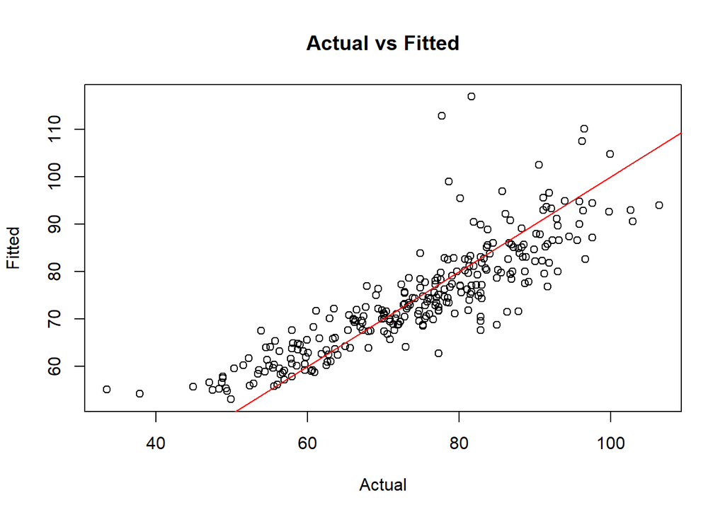

```r
#A scatter plot of actual salary vs fitted values
plot(x=salary$salary,y=fit1$fitted.values,
     xlab="Actual",ylab="Fitted",main="Actual vs Fitted")
#Plot a linear line where intercept=0 and slope=1
abline(a=0,b=1,col="red")
```

The residuals are also stored in the model object and can be called upon readily for diagnostic plots and assessments. Let us explore some of these features below.

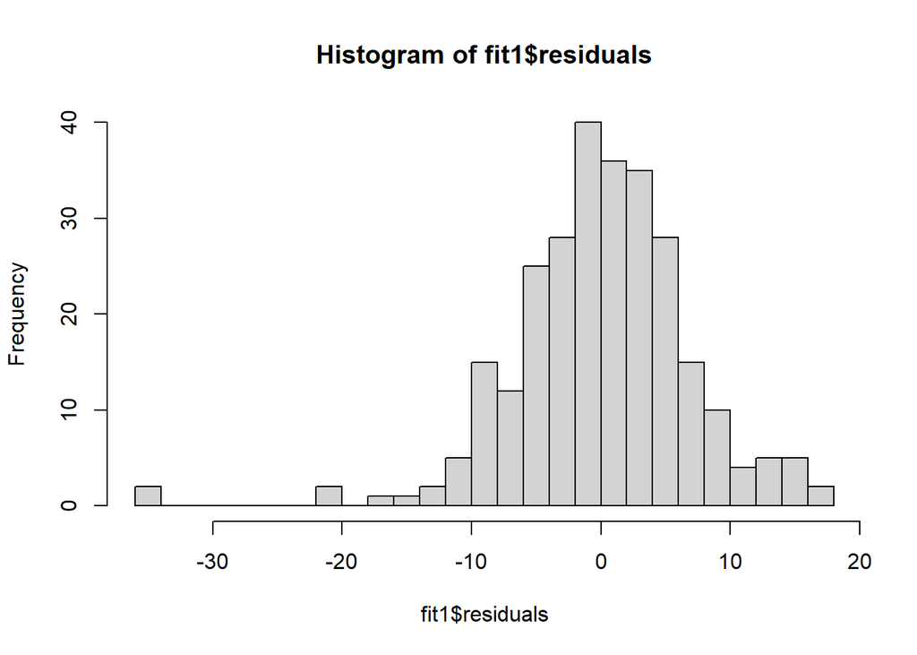

```r
#Plot of residual histogram
hist(fit1$residuals,25)
```

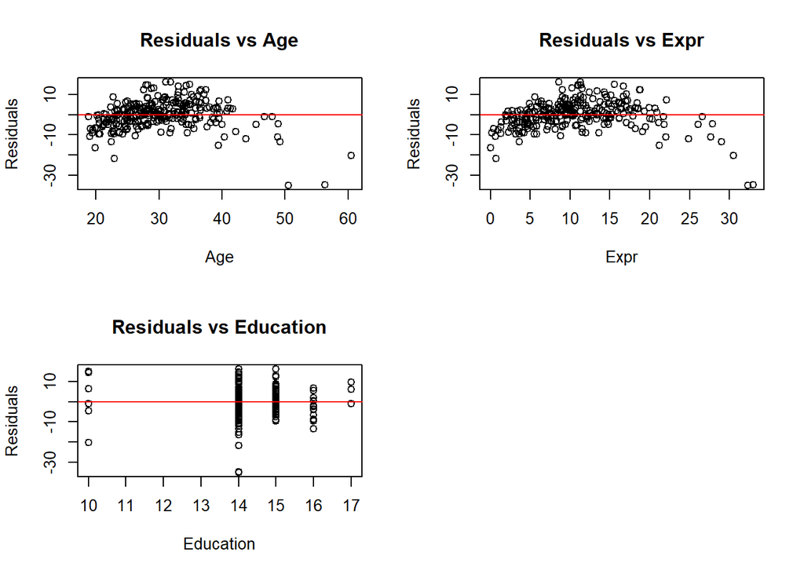

```r
#Scatter of residuals vs fitted values and residuals vs Expr
par(mfrow=c(2,2))
plot(x=salary$age,y=fit1$residuals,xlab="Age",ylab="Residuals",
     main="Residuals vs Age")
abline(a=0,b=0,col="red")
plot(x=salary$Expr,y=fit1$residuals,xlab="Expr",ylab="Residuals",
     main="Residuals vs Expr")
abline(a=0,b=0,col="red")
plot(x=salary$education,y=fit1$residuals,xlab="Education",ylab="Residuals",
     main="Residuals vs Education")
abline(a=0,b=0,col="red")
```

The histogram of the residuals shows that it is indeed centred around zero. However, we can see that negative residuals can be twice as large as positive residuals, with the histogram showing a negatively skewed residual distribution.

The scatter plot of the residuals against the regressor variables reveal how these extreme negative residuals are realized. At the lower and upper boundary of experience (and age), we see much larger negative magnitude residuals compared to the middle region. This implies that in those regions of experience, a linear function does not fit well, and we potentially need nonlinear structure to capture the relationship between experience and salary.

The plot of residual against education also reveal an apparent feature of the education variable. By definition, the education variable should be treated as dummy variables as each numeric level (10, 14, 15, 16, 17) are simply labels of different qualifications rather than the number of years of education.

Note that these tools allow you to “diagnose” where the model misfits, but it does not provide you with a “solution” of how to fix it. That is the modeller’s choice!

### Accounting for Nonlinear Effects - Does the result change with more accurate model?

To account for the apparent nonlinear pattern in the age and experience variable, we will consider additing quadratic effects for both variables. We need to also reclassify the education variable as a “factor” variable so that it can be modelled using dummy variable techniques.

Note that R allows you to specify an arithmatic expression within the “lm” formula using the I() wrapper function.

```r
#reclassify education as a factor variable
salary$education=as.factor(salary$education)
#Fit a nonlinear regression model
fit2=lm(salary~age+I(age^2)+Expr+I(Expr^2)+education+Gender,data=salary)
#Improved model summary
summary(fit2)
```

```
##
## Call:
## lm(formula = salary ~ age + I(age^2) + Expr + I(Expr^2) + education +
##     Gender, data = salary)
##
## Residuals:
##      Min       1Q   Median       3Q      Max
## -14.3369  -2.7470   0.0065   3.1985  13.6816
##
## Coefficients:
##              Estimate Std. Error t value Pr(>|t|)
## (Intercept) 19.843726   7.222297   2.748 0.006419 **
## age          1.111712   0.523075   2.125 0.034491 *
## I(age^2)    -0.015962   0.007986  -1.999 0.046660 *
## Expr         3.860597   0.292819  13.184  < 2e-16 ***
## I(Expr^2)   -0.073208   0.010733  -6.821 6.20e-11 ***
## education14  2.778051   2.185840   1.271 0.204876
## education15  8.985018   2.296248   3.913 0.000116 ***
## education16  9.455017   2.568407   3.681 0.000282 ***
## education17 20.246430   3.561149   5.685 3.46e-08 ***
## GenderM      2.243056   0.680384   3.297 0.001113 **
## ---
## Signif. codes:  0 '***' 0.001 '**' 0.01 '*' 0.05 '.' 0.1 ' ' 1
##
## Residual standard error: 4.832 on 263 degrees of freedom
## Multiple R-squared:  0.8764, Adjusted R-squared:  0.8722
## F-statistic: 207.3 on 9 and 263 DF,  p-value: < 2.2e-16
```

This refined model now takes into account the nonlinear relationship in age and experience, as well as the fact that the numeric records for the education variable are simply labels of different levels of qualification. The residual of this model is much better behaved than that of the simple model. The histogram of the residual roughly equal proportion of positive and negative residuals of similar magnitudes. The residuals are scattered randomly against the explanatory variables, indicating that we have captured the nonlinear relations well with this model.

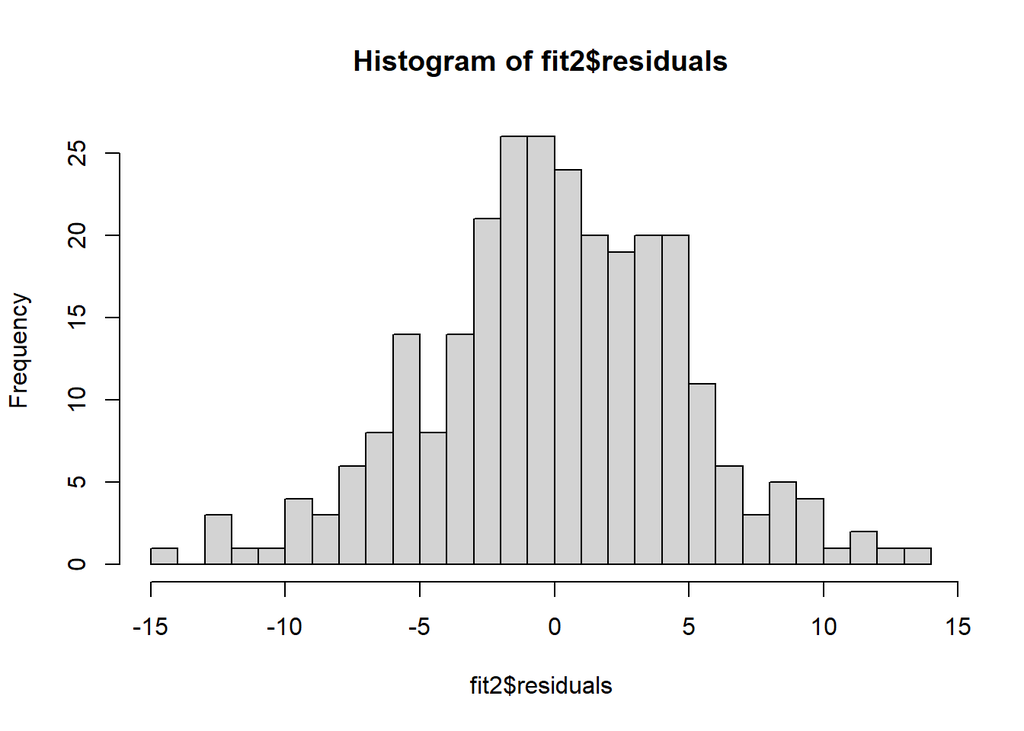

```r
#Plot of residual histogram
hist(fit2$residuals,25)
```

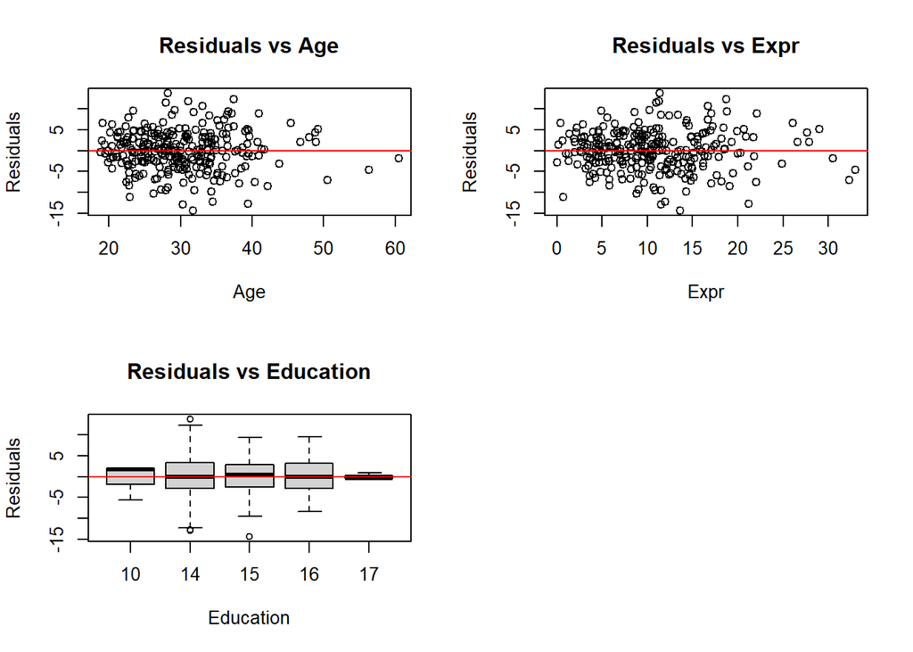

```r
#Scatter of residuals vs fitted values and residuals vs Expr
par(mfrow=c(2,2))
plot(x=salary$age,y=fit2$residuals,xlab="Age",ylab="Residuals",
     main="Residuals vs Age")
abline(a=0,b=0,col="red")
plot(x=salary$Expr,y=fit2$residuals,xlab="Expr",ylab="Residuals",
     main="Residuals vs Expr")
abline(a=0,b=0,col="red")
plot(x=salary$education,y=fit2$residuals,xlab="Education",ylab="Residuals",
     main="Residuals vs Education")
abline(a=0,b=0,col="red")
```

Under this more complex model, the analysis reveal that the salary differential between male and female is $2,243, given that both parties are of the same age, have equal work experience (measured in years), as well as hold the same qualification. This amounts to 3.35% differential in salary on average.

```r
#Model implied differential - in percentage
100*fit2$coefficients["GenderM"]/mean_F
```

```
##  GenderM
## 3.351961
```

Recall that in the pairwise assessment we conducted using the t-test of sample mean difference, the differential salary is 15.5% on average. What could be the driving factors of this vastly different estimate of the salary differential?

### What drives the difference in the pairwise assessment and the complex regression assessment?

Let us explore the data deeper into the profiles of the individuals represented in this dataset.

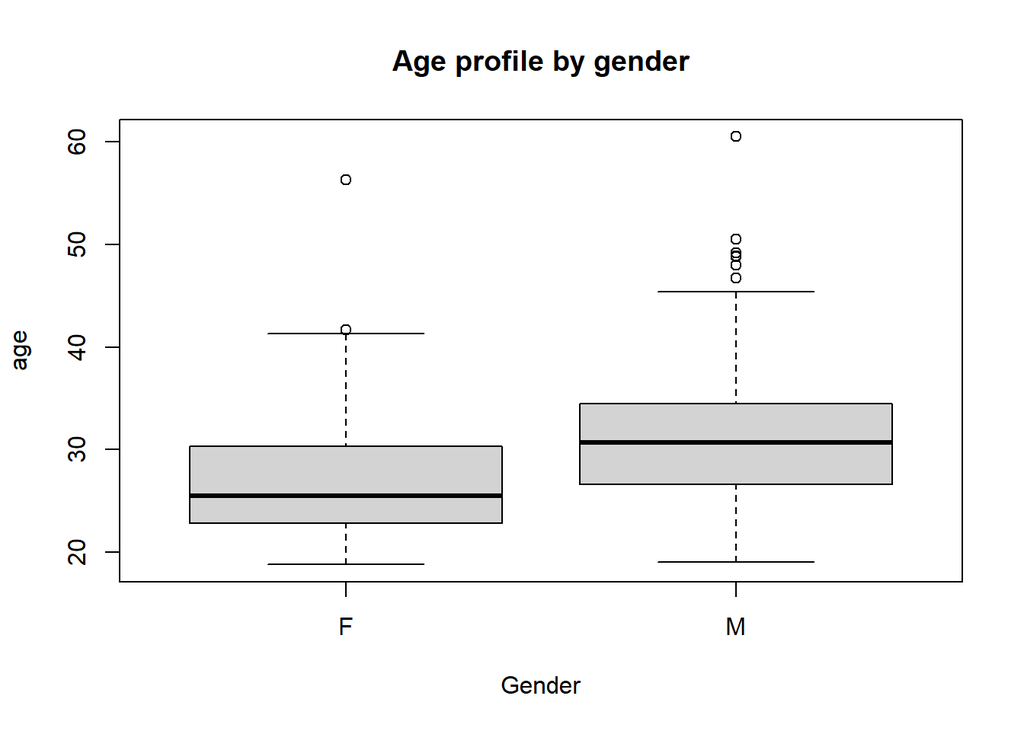

```r
#Age and experience profiles are captured by box plots
#Here, we plot both variables, segmented by gender
boxplot(age~Gender,data=salary,main="Age profile by gender")
```

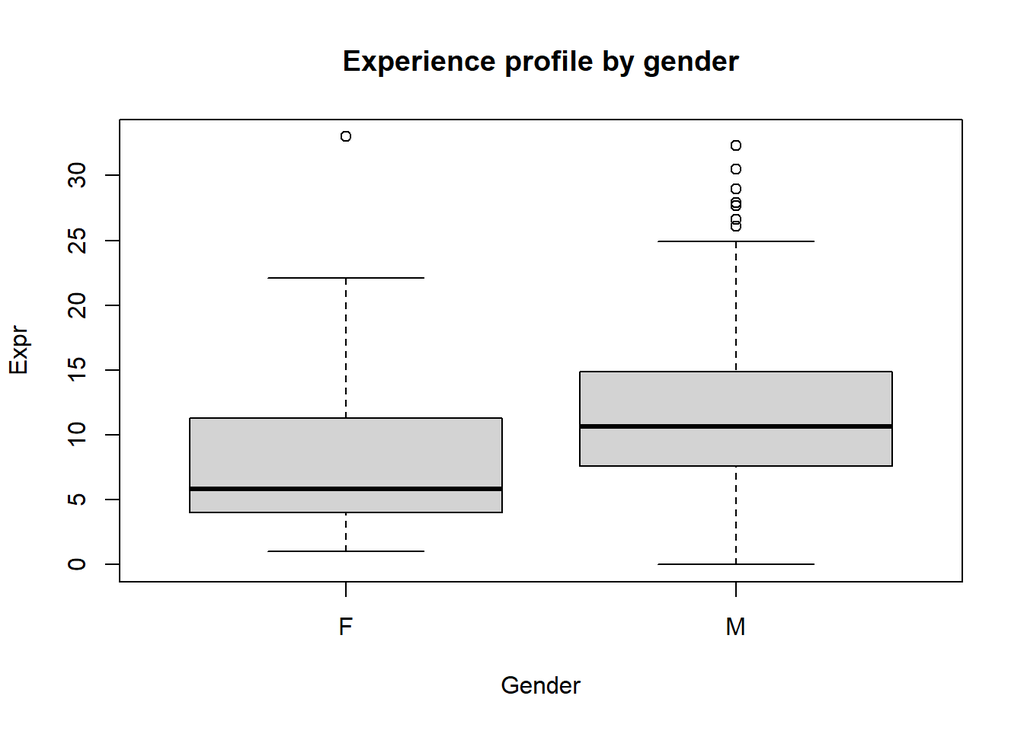

```r
boxplot(Expr~Gender,data=salary,main="Experience profile by gender")
```

```r
#The relative frequency table is used to compare the education profile
FEduc=100*table(salary$education[salary$Gender=="F"])/sum(salary$Gender=="F")
MEduc=100*table(salary$education[salary$Gender=="M"])/sum(salary$Gender=="M")
FEduc
```

```
##
##        10        14        15        16        17
##  1.265823 62.025316 25.316456 10.126582  1.265823
```

```r
MEduc
```

```
##
##        10        14        15        16        17
##  2.577320 70.103093 22.680412  3.608247  1.030928
```

The characteristic profile reveal that the female group tend to be younger and has less experience than their male counterparts. It also reveals that there is a larger proportion of postgraduate/PhD degree holders in the female group (11.4% vs 4.6%). This implies that more of the female individuals are taking up higher education and forgoing work experience. Coupled with the younger age profile in this group, the salary differential has been overestimated when the pairwise assessment technique is used.

To this end, the analysis points to the fact that the majority of the salary differential is driven by the differing age profile, and the choice made by females in the education and work experience tradeoff. The question remains as to what is the major driver to the 3.35% salary differential concluded by the more complex model, and whether this salary differential is economically significant to warrant a case of pay equity dispute.